# Beggs-Brill correlation

2019-07-31

## How do we find the limits of accuracy in the `BB` correlation

### Get `z` at selected `Ppr` and `Tpr`

```r
# get a z value using DPR correlation
library(zFactor)

z.BeggsBrill(pres.pr = 1.5, temp.pr = 2.0)
# HY = 0.9580002
```

```
[1] 0.962902
```

From the Standing-Katz chart we obtain a digitized point at the same `Ppr` and `Tpr`:

```r
# get a z value from the SK chart at the same Ppr and Tpr
library(zFactor)

tpr_vec <- c(2.0)
getStandingKatzMatrix(tpr_vector = tpr_vec,
                      pprRange = "lp")[1, "1.5"]
```

```
  1.5
0.956
```

It looks pretty good.

### Get `z` at selected `Ppr` and `Tpr`

```r
library(zFactor)
z.BeggsBrill(pres.pr = 1.5, temp.pr = 1.1)
```

```
[1] 0.4631501
```

From the `Standing-Katz` chart we obtain a digitized point:

```r
library(zFactor)
tpr_vec <- c(1.1)
getStandingKatzMatrix(tpr_vector = tpr_vec,
                      pprRange = "lp")[1, "1.5"]
```

```
  1.5
0.426
```

> At lower `Tpr` there is some error. We see a difference between the values of z from the `BB calculation and the value read from the Standing-Katz chart.

## Get values of `z` for several `Ppr` and `Tpr`

```r
# test HY with 1st-derivative using the values from paper

ppr <- c(0.5, 1.5, 2.5, 3.5, 4.5, 5.5, 6.5)
tpr <- c(1.3, 1.5, 1.7, 2)

corr <- z.BeggsBrill(pres.pr = ppr, temp.pr = tpr)
print(corr)

# From Hall-Yarborough
#    0.5       1.5       2.5       3.5       4.5       5.5       6.5
# 1.3 0.9176300 0.7534433 0.6399020 0.6323003 0.6881127 0.7651710 0.8493794
# 1.5 0.9496855 0.8581232 0.7924067 0.7687902 0.7868071 0.8316848 0.8906351
# 1.7 0.9682547 0.9134862 0.8756412 0.8605668 0.8694525 0.8978885 0.9396353
# 2   0.9838234 0.9580002 0.9426939 0.9396286 0.9490995 0.9697839 0.9994317

# From Dranchuk-AbouKassem
#  0.5       1.5       2.5       3.5       4.5       5.5       6.5
# 1.3 0.9203019 0.7543694 0.6377871 0.6339357 0.6898314 0.7663247 0.8499523
# 1.5 0.9509373 0.8593144 0.7929993 0.7710525 0.7896224 0.8331893 0.8904317
# 1.7 0.9681353 0.9128087 0.8753784 0.8619509 0.8721085 0.9003962 0.9409634
# 2   0.9824731 0.9551087 0.9400752 0.9385273 0.9497137 0.9715388 1.0015560
```

```
          0.5       1.5       2.5       3.5       4.5       5.5       6.5
1.3 0.9266436 0.7675523 0.6526911 0.6234648 0.6921991 0.7779095 0.8630653
1.5 0.9555248 0.8618306 0.7945385 0.7691830 0.7828753 0.8248905 0.8837555
1.7 0.9719193 0.9159219 0.8728791 0.8521620 0.8556641 0.8800665 0.9198223
2   0.9853337 0.9629020 0.9471826 0.9404180 0.9443010 0.9593080 0.9848256
```

With the same `ppr` and `tpr` vectors, we do the same for the Standing-Katz chart:

```r
library(zFactor)

sk <- getStandingKatzMatrix(ppr_vector = ppr, tpr_vector = tpr)
print(sk)
```

```
       0.5   1.5   2.5   3.5   4.5   5.5   6.5
1.30 0.916 0.756 0.638 0.633 0.684 0.759 0.844
1.50 0.948 0.859 0.794 0.770 0.790 0.836 0.892
1.70 0.968 0.914 0.876 0.857 0.864 0.897 0.942
2.00 0.982 0.956 0.941 0.937 0.945 0.969 1.003
```

Subtract the two matrices and find the difference:

```r
err <- round((sk - corr) / sk * 100, 2)
err

# DAK
# 0.5   1.5  2.5   3.5   4.5   5.5   6.5
# 1.30 -0.47  0.22 0.03 -0.15 -0.85 -0.97 -0.71
# 1.50 -0.31 -0.04 0.13 -0.14  0.05  0.34  0.18
# 1.70 -0.01  0.13 0.07 -0.58 -0.94 -0.38  0.11
# 2.00 -0.05  0.09 0.10 -0.16 -0.50 -0.26  0.14
```

```
       0.5   1.5   2.5   3.5   4.5   5.5   6.5
1.30 -1.16 -1.53 -2.30  1.51 -1.20 -2.49 -2.26
1.50 -0.79 -0.33 -0.07  0.11  0.90  1.33  0.92
1.70 -0.40 -0.21  0.36  0.56  0.96  1.89  2.35
2.00 -0.34 -0.72 -0.66 -0.36  0.07  1.00  1.81
```

## Error by `Ppr` and by `PPr`

```r
print(colSums(err))
```

```
  0.5   1.5   2.5   3.5   4.5   5.5   6.5
-2.69 -2.79 -2.67  1.82  0.73  1.73  2.82
```

```r
print(rowSums(err))
```

```
 1.30  1.50  1.70  2.00
-9.43  2.07  5.51  0.80
```

## Analyze the error for smaller values of `Tpr`

```r
library(zFactor)

tpr2 <- c(1.05, 1.1)
ppr2 <- c(0.5, 1.5, 2.5, 3.5, 4.5, 5.5)

sk2 <- getStandingKatzMatrix(ppr_vector = ppr2, tpr_vector = tpr2, pprRange = "lp")
sk2
```

```
       0.5   1.5   2.5   3.5   4.5   5.5
1.05 0.829 0.253 0.343 0.471 0.598 0.727
1.10 0.854 0.426 0.393 0.500 0.615 0.729
```

We do the same with the `BB` correlation:

```r
# calculate z values at lower values of Tpr
library(zFactor)

corr2 <- z.BeggsBrill(pres.pr = ppr2, temp.pr = tpr2)
print(corr2)
```

```
           0.5       1.5       2.5       3.5       4.5       5.5
1.05 0.8325491 0.2851494 0.3333796 0.4569204 0.5802310 0.7033638
1.1  0.8639321 0.4631501 0.3848774 0.4993213 0.6131885 0.7266084
```

Subtract the matrices and calculate the error in percentage:

```r
err2 <- round((sk2 - corr2) / sk2 * 100, 2)
err2

# DAK
# 0.5    1.5    2.5   3.5   4.5   5.5
# 1.05 -0.13 -12.15 -12.78 -7.49 -4.34 -1.68
# 1.10 -0.36  -4.79  -4.97 -3.56 -2.14 -1.21
```

```
       0.5    1.5  2.5  3.5  4.5  5.5
1.05 -0.43 -12.71 2.80 2.99 2.97 3.25
1.10 -1.16  -8.72 2.07 0.14 0.29 0.33
```

Transposing the matrix with `Tpr` as columns and `Ppr` as rows:

```r
t_err2 <- t(err2)
t_err2
```

```
      1.05  1.10
0.5  -0.43 -1.16
1.5 -12.71 -8.72
2.5   2.80  2.07
3.5   2.99  0.14
4.5   2.97  0.29
5.5   3.25  0.33
```

A statistical summary by `Tpr` curve:

```r
sum_t_err2 <- summary(t_err2)
sum_t_err2
```

```
      1.05               1.10
 Min.   :-12.7100   Min.   :-8.720
 1st Qu.:  0.3775   1st Qu.:-0.835
 Median :  2.8850   Median : 0.215
 Mean   : -0.1883   Mean   :-1.175
 3rd Qu.:  2.9850   3rd Qu.: 0.320
 Max.   :  3.2500   Max.   : 2.070
```

## Prepare to plot `SK` chart vs `BB` correlation

```r
library(zFactor)
library(tibble)

tpr2 <- c(1.05, 1.1, 1.2, 1.3)
ppr2 <- c(0.5, 1.0, 1.5, 2, 2.5, 3.0, 3.5, 4.0, 4.5, 5.0, 5.5, 6.0, 6.5)

sk_corr_2 <- createTidyFromMatrix(ppr2, tpr2, correlation = "BB")
as.tibble(sk_corr_2)
```

```
# A tibble: 52 x 5
   Tpr     Ppr z.chart z.calc      dif
   <chr> <dbl>   <dbl>  <dbl>    <dbl>
 1 1.05    0.5   0.829  0.833 -0.00355
 2 1.1     0.5   0.854  0.864 -0.00993
 3 1.2     0.5   0.893  0.903 -0.00965
 4 1.3     0.5   0.916  0.927 -0.0106
 5 1.05    1     0.589  0.586  0.00330
 6 1.1     1     0.669  0.687 -0.0184
 7 1.2     1     0.779  0.790 -0.0109
 8 1.3     1     0.835  0.845 -0.00951
 9 1.05    1.5   0.253  0.285 -0.0321
10 1.1     1.5   0.426  0.463 -0.0372
# … with 42 more rows
```

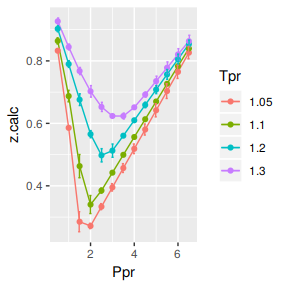

```r
library(ggplot2)

p <- ggplot(sk_corr_2, aes(x=Ppr, y=z.calc, group=Tpr, color=Tpr)) +
    geom_line() +
    geom_point() +
    geom_errorbar(aes(ymin=z.calc-dif, ymax=z.calc+dif), width=.4,
                  position=position_dodge(0.05))
print(p)
```

## Analysis at the lowest `Tpr`

Extract only values at `Tpr = 1.05`.

```r
sk_corr_3 <- sk_corr_2[sk_corr_2$Tpr==1.05,]
sk_corr_3
```

```
    Tpr Ppr z.chart    z.calc          dif
1  1.05 0.5   0.829 0.8325491 -0.003549064
5  1.05 1.0   0.589 0.5857006  0.003299370
9  1.05 1.5   0.253 0.2851494 -0.032149397
13 1.05 2.0   0.280 0.2715884  0.008411630
17 1.05 2.5   0.343 0.3333796  0.009620404
21 1.05 3.0   0.407 0.3951833  0.011816743
25 1.05 3.5   0.471 0.4569204  0.014079649
29 1.05 4.0   0.534 0.5186005  0.015399484
33 1.05 4.5   0.598 0.5802310  0.017769048
37 1.05 5.0   0.663 0.6418172  0.021182758
41 1.05 5.5   0.727 0.7033638  0.023636157
45 1.05 6.0   0.786 0.7648744  0.021125603
49 1.05 6.5   0.846 0.8263519  0.019648067
```

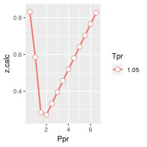

```r
p <- ggplot(sk_corr_3, aes(x=Ppr, y=z.calc, group=Tpr, color=Tpr)) +
    geom_line(size = 1) +
    geom_point(shape = 21, fill = "white", size = 3) +
    geom_errorbar(aes(ymin=z.calc-dif, ymax=z.calc+dif), width=0.2, size = 0.,
                  position=position_dodge(0.05), color = "black")
print(p)
```

```r
summary(sk_corr_3)

 #         dif DAK
 # Min.   :-0.048404
 # 1st Qu.:-0.035300
 # Median :-0.025978
 # Mean   :-0.023178
 # 3rd Qu.:-0.009960
 # Max.   : 0.002325
```

```
     Tpr                 Ppr         z.chart           z.calc
 Length:13          Min.   :0.5   Min.   :0.2530   Min.   :0.2716
 Class :character   1st Qu.:2.0   1st Qu.:0.4070   1st Qu.:0.3952
 Mode  :character   Median :3.5   Median :0.5890   Median :0.5802
                    Mean   :3.5   Mean   :0.5635   Mean   :0.5535
                    3rd Qu.:5.0   3rd Qu.:0.7270   3rd Qu.:0.7034
                    Max.   :6.5   Max.   :0.8460   Max.   :0.8325
      dif
 Min.   :-0.032149
 1st Qu.: 0.008412
 Median : 0.014080
 Mean   : 0.010022
 3rd Qu.: 0.019648
 Max.   : 0.023636
```

With this information there is no much we can say about Beggs-Brill.

## Analyzing performance of the `BB` correlation for all the `Tpr` curves

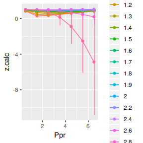

```
# A tibble: 112 x 5
   Tpr     Ppr z.chart z.calc      dif
   <chr> <dbl>   <dbl>  <dbl>    <dbl>
 1 1.05    0.5   0.829  0.833 -0.00355
 2 1.1     0.5   0.854  0.864 -0.00993
 3 1.2     0.5   0.893  0.903 -0.00965
 4 1.3     0.5   0.916  0.927 -0.0106
 5 1.4     0.5   0.936  0.943 -0.00730
 6 1.5     0.5   0.948  0.956 -0.00752
 7 1.6     0.5   0.959  0.965 -0.00578
 8 1.7     0.5   0.968  0.972 -0.00392
 9 1.8     0.5   0.974  0.977 -0.00349
10 1.9     0.5   0.978  0.982 -0.00386
# … with 102 more rows
```

```r
library(ggplot2)
library(tibble)

# get all `lp` Tpr curves
tpr_all <- getStandingKatzTpr(pprRange = "lp")
ppr <- c(0.5, 1.5, 2.5, 3.5, 4.5, 5.5, 6.5)

sk_corr_all <- createTidyFromMatrix(ppr, tpr_all, correlation = "BB")
as.tibble(sk_corr_all)

p <- ggplot(sk_corr_all, aes(x=Ppr, y=z.calc, group=Tpr, color=Tpr)) +
    geom_line() +
    geom_point() +
    geom_errorbar(aes(ymin=z.calc-dif, ymax=z.calc+dif), width=.4,
                  position=position_dodge(0.05))
print(p)
```

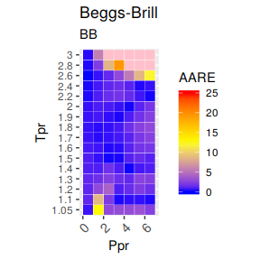

```r
# MSE: Mean Squared Error
# RMSE: Root Mean Sqyared Error
# RSS: residual sum of square
# ARE:  Average Relative Error, %
# AARE: Average Absolute Relative Error, %
library(dplyr)
grouped <- group_by(sk_corr_all, Tpr, Ppr)
smry_tpr_ppr <- summarise(grouped,
          RMSE= sqrt(mean((z.chart-z.calc)^2)),
          MSE = sum((z.calc - z.chart)^2) / n(),
          RSS = sum((z.calc - z.chart)^2),
          ARE = sum((z.calc - z.chart) / z.chart) * 100 / n(),
          AARE = sum( abs((z.calc - z.chart) / z.chart)) * 100 / n()
          )

ggplot(smry_tpr_ppr, aes(Ppr, Tpr)) +
    geom_tile(data=smry_tpr_ppr, aes(fill=AARE), color="white") +
    scale_fill_gradient2(low="blue", high="red", mid="yellow", na.value = "pink",
                         midpoint=12.5, limit=c(0, 25), name="AARE") +
    theme(axis.text.x = element_text(angle=45, vjust=1, size=11, hjust=1)) +
    coord_equal() +
    ggtitle("Beggs-Brill", subtitle = "BB")
```

> The errors with Beggs and Brill are just so big and some `z` values are even negative. We have to be very careful when using this Beggs and Brill correlation.

## Plotting the Tpr and Ppr values that show more error

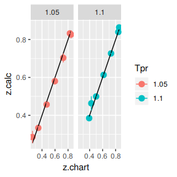

```r
library(dplyr)

sk_corr_all %>%
    filter(Tpr %in% c("1.05", "1.1")) %>%
    ggplot(aes(x = z.chart, y=z.calc, group = Tpr, color = Tpr)) +
    geom_point(size = 3) +
    geom_line(aes(x = z.chart, y = z.chart), color = "black") +
    facet_grid(. ~ Tpr) +
    geom_errorbar(aes(ymin=z.calc-abs(dif), ymax=z.calc+abs(dif)),
                  position=position_dodge(0.5))
```

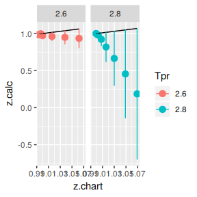

```r
library(dplyr)

sk_corr_all %>%
    filter(Tpr %in% c("2.6", "2.8")) %>%
    ggplot(aes(x = z.chart, y=z.calc, group = Tpr, color = Tpr)) +
    geom_point(size = 3) +
    geom_line(aes(x = z.chart, y = z.chart), color = "black") +
    facet_grid(. ~ Tpr) +
    geom_errorbar(aes(ymin=z.calc-abs(dif), ymax=z.calc+abs(dif)),
                  position=position_dodge(0.5))
```

Let’s see which observations (rows) have `z` values that are negative:

```r
sk_corr_all[which(sk_corr_all$z.calc < 0), ]
```

```
    Tpr Ppr z.chart    z.calc      dif
80    3 4.5   1.041 -0.889701 1.930701
96    3 5.5   1.056 -2.517895 3.573895
112   3 6.5   1.075 -4.882513 5.957513
```

Or see which rows contain `z` values that show an error greater than 15%:

```r
sk_corr_all[which(abs(sk_corr_all$dif) > 0.15), ]
```

```
    Tpr Ppr z.chart     z.calc       dif
48    3 2.5   1.018  0.7082371 0.3097629
63  2.8 3.5   1.016  0.8188474 0.1971526
64    3 3.5   1.029  0.1399229 0.8890771
79  2.8 4.5   1.030  0.6645377 0.3654623
80    3 4.5   1.041 -0.8897010 1.9307010
95  2.8 5.5   1.049  0.4548462 0.5941538
96    3 5.5   1.056 -2.5178952 3.5738952
111 2.8 6.5   1.069  0.1860147 0.8829853
112   3 6.5   1.075 -4.8825128 5.9575128
```

You can also see that there are three rows with error greater than 100% !

## Looking numerically at the errors in `BB` vs `SK` chart

```r
# get all `lp` Tpr curves
tpr <- getStandingKatzTpr(pprRange = "lp")
ppr <- c(0.5, 1.5, 2.5, 3.5, 4.5, 5.5, 6.5)

# calculate HY for the given Tpr
all_corr <- z.BeggsBrill(pres.pr = ppr, temp.pr = tpr)
cat("Calculated from the correlation \n")
print(all_corr)

cat("\nStanding-Katz chart\n")
all_sk <- getStandingKatzMatrix(ppr_vector = ppr, tpr_vector = tpr)
all_sk

# find the error
cat("\n Errors in percentage \n")
all_err <- round((all_sk - all_corr) / all_sk * 100, 2)  # in percentage
all_err

cat("\n Errors in Ppr\n")
summary(all_err)

# for the transposed matrix
cat("\n Errors for the transposed matrix: Tpr \n")
summary(t(all_err))
```

```
Calculated from the correlation
           0.5       1.5       2.5       3.5        4.5        5.5
1.05 0.8325491 0.2851494 0.3333796 0.4569204  0.5802310  0.7033638
1.1  0.8639321 0.4631501 0.3848774 0.4993213  0.6131885  0.7266084
1.2  0.9026461 0.6758659 0.4977865 0.5605500  0.6589953  0.7567099
1.3  0.9266436 0.7675523 0.6526911 0.6234648  0.6921991  0.7779095
1.4  0.9432988 0.8224273 0.7388187 0.7103492  0.7343367  0.7966791
1.5  0.9555248 0.8618306 0.7945385 0.7691830  0.7828753  0.8248905
1.6  0.9647818 0.8920527 0.8376331 0.8139976  0.8214333  0.8532880
1.7  0.9719193 0.9159219 0.8728791 0.8521620  0.8556641  0.8800665
1.8  0.9774854 0.9350585 0.9022222 0.8855750  0.8874829  0.9067399
1.9  0.9818623 0.9504907 0.9267646 0.9149047  0.9171073  0.9333359
2    0.9853337 0.9629020 0.9471826 0.9404180  0.9443010  0.9593080
2.2  0.9904020 0.9803535 0.9768810 0.9795480  0.9887829  1.0049837
2.4  0.9940266 0.9894204 0.9909094 0.9974289  1.0086828  1.0246183
2.6  0.9971532 0.9902007 0.9817596 0.9719460  0.9608415  0.9485126
2.8  1.0004100 0.9802574 0.9222416 0.8188474  0.6645377  0.4548462
3    1.0040392 0.9514557 0.7082371 0.1399229 -0.8897010 -2.5178952
            6.5
1.05  0.8263519
1.1   0.8396647
1.2   0.8538299
1.3   0.8630653
1.4   0.8717561
1.5   0.8837555
1.6   0.9011787
1.7   0.9198223
1.8   0.9400764
1.9   0.9619430
2     0.9848256
2.2   1.0282971
2.4   1.0452638
2.6   0.9350177
2.8   0.1860147
3    -4.8825128

Standing-Katz chart
       0.5   1.5   2.5   3.5   4.5   5.5   6.5
1.05 0.829 0.253 0.343 0.471 0.598 0.727 0.846
1.10 0.854 0.426 0.393 0.500 0.615 0.729 0.841
```

[output cut: 64 more lines]

```
 Max.   :-0.0500   Max.   : 1.3300   Max.   : 1.83   Max.   : 2.3500
      1.80             1.90              2.00              2.20
 Min.   :-0.360   Min.   :-0.5800   Min.   :-0.7200   Min.   :-1.7200
 1st Qu.: 0.045   1st Qu.:-0.3450   1st Qu.:-0.5100   1st Qu.:-1.3750
 Median : 0.610   Median : 0.1200   Median :-0.3400   Median :-0.7600
 Mean   : 1.003   Mean   : 0.5129   Mean   : 0.1143   Mean   :-0.8286
 3rd Qu.: 1.950   3rd Qu.: 1.2000   3rd Qu.: 0.5350   3rd Qu.:-0.3200
 Max.   : 2.780   Max.   : 2.3400   Max.   : 1.8100   Max.   : 0.0700
      2.40              2.60             2.80            3.00
 Min.   :-1.4700   Min.   :-0.020   Min.   :-0.14   Min.   : -0.20
 1st Qu.:-1.0400   1st Qu.: 0.805   1st Qu.: 5.34   1st Qu.: 18.07
 Median :-0.5500   Median : 2.810   Median :19.40   Median : 86.40
 Mean   :-0.5714   Mean   : 4.344   Mean   :29.24   Mean   :171.49
 3rd Qu.:-0.1300   3rd Qu.: 7.025   3rd Qu.:46.06   3rd Qu.:261.95
 Max.   : 0.3600   Max.   :11.960   Max.   :82.60   Max.   :554.19
```